# U.S. Medical Insurance Costs Analysis

```python
import csv
import numpy as np
import pandas as pd
from matplotlib import pyplot as plt
import seaborn as sns
```

First step would be reading the csv file as a dataframe and exploring the given variables

```python
ins = pd.read_csv('insurance.csv')
ins.head(10)
```

|  | age | sex | bmi | children | smoker | region | charges |
| --- | --- | --- | --- | --- | --- | --- | --- |
| 0 | 19 | female | 27.900 | 0 | yes | southwest | 16884.92400 |
| 1 | 18 | male | 33.770 | 1 | no | southeast | 1725.55230 |
| 2 | 28 | male | 33.000 | 3 | no | southeast | 4449.46200 |
| 3 | 33 | male | 22.705 | 0 | no | northwest | 21984.47061 |
| 4 | 32 | male | 28.880 | 0 | no | northwest | 3866.85520 |
| 5 | 31 | female | 25.740 | 0 | no | southeast | 3756.62160 |
| 6 | 46 | female | 33.440 | 1 | no | southeast | 8240.58960 |
| 7 | 37 | female | 27.740 | 3 | no | northwest | 7281.50560 |
| 8 | 37 | male | 29.830 | 2 | no | northeast | 6406.41070 |
| 9 | 60 | female | 25.840 | 0 | no | northwest | 28923.13692 |

Lets look into the type of variables there are in the data frame

```python
ins.info()
```

```
<class 'pandas.core.frame.DataFrame'>
RangeIndex: 1338 entries, 0 to 1337
Data columns (total 7 columns):
 #   Column    Non-Null Count  Dtype
---  ------    --------------  -----
 0   age       1338 non-null   int64
 1   sex       1338 non-null   object
 2   bmi       1338 non-null   float64
 3   children  1338 non-null   int64
 4   smoker    1338 non-null   object
 5   region    1338 non-null   object
 6   charges   1338 non-null   float64
dtypes: float64(2), int64(2), object(3)
memory usage: 73.3+ KB
```

```python
ins.describe()
```

|  | age | bmi | children | charges |
| --- | --- | --- | --- | --- |
| count | 1338.000000 | 1338.000000 | 1338.000000 | 1338.000000 |
| mean | 39.207025 | 30.663397 | 1.094918 | 13270.422265 |
| std | 14.049960 | 6.098187 | 1.205493 | 12110.011237 |
| min | 18.000000 | 15.960000 | 0.000000 | 1121.873900 |
| 25% | 27.000000 | 26.296250 | 0.000000 | 4740.287150 |
| 50% | 39.000000 | 30.400000 | 1.000000 | 9382.033000 |
| 75% | 51.000000 | 34.693750 | 2.000000 | 16639.912515 |
| max | 64.000000 | 53.130000 | 5.000000 | 63770.428010 |

There are seven variables, two are integers, two are floats and 1338 entries. The average age of insurance clients is 39 years with average bmi equal to 30. On avrage insurance clients have 1 child and are charged 13270 on average. Question that this research is going to look into are:

- What are the average insurance charges in each region?
- How age affects the insurance charges?
- What is the average bmi for female vs male?
- What is the smoker vs non-smoker ration among clients?

### 1. What are the average insurance charges in each region?

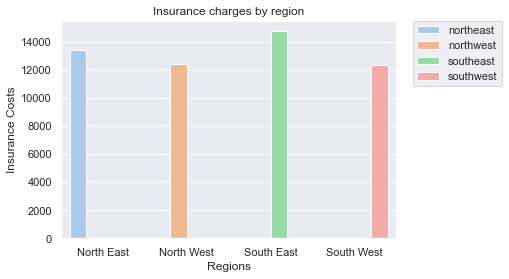

```python
ins_region = ins.groupby(['region']).charges.mean().reset_index()
pivoted_ins_region = ins_region.pivot(columns = 'region', values = 'charges')

sns.set_theme(palette="pastel")
ax = sns.barplot(x = 'region', y = 'charges', data = ins_region, hue='region')
plt.legend(bbox_to_anchor = (1.05, 1), loc = 2, borderaxespad = 0.)
plt.title('Insurance charges by region')
ax.set_xticklabels(['North East', 'North West', 'South East', 'South West'])
ax.set_xlabel('Regions')
ax.set_ylabel('Insurance Costs')
plt.show()
```

As we can see the highest insurance charges are in South East region, whereas the lowest charges are in South West region. The average prices in all region do not fall below 12000 USD. Next step would be looking into the number of clients for each region to see if some regino might have a bigger client base than others.

```python
ins_by_region = ins.groupby('region').bmi.count().reset_index()
ins_by_region
```

|  | region | bmi |
| --- | --- | --- |
| 0 | northeast | 324 |
| 1 | northwest | 325 |
| 2 | southeast | 364 |
| 3 | southwest | 325 |

The number of clients in each region do not differe drastically. The most clients are in South East region and the least number of clients is in North East. North West and South West have the same number of clients equal to 325.

### 2. How age affects the insurance charges?

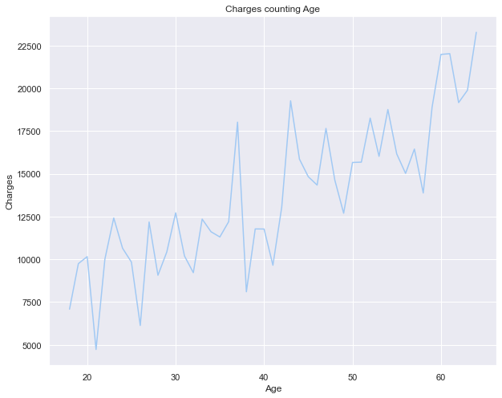

```python
ins_age = ins.groupby('age').charges.mean().reset_index()
plt.figure(figsize=(10, 8))
plt.plot(ins_age.age, ins_age.charges)
plt.title('Charges counting Age')
plt.xlabel('Age', fontsize=12)
plt.ylabel('Charges', fontsize=12)
plt.show()
```

As we can see above, there is a correlation between age and insurance charges. With gae a client is more likely to double their insurance charges.

### 3. What is the average bmi for female vs male?

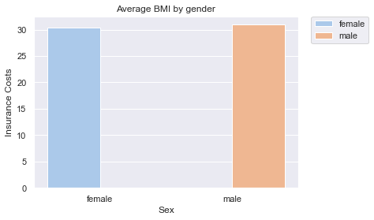

```python
ins_bmi = ins.groupby(['sex']).bmi.mean().reset_index()
pivoted_ins_bmi = ins_bmi.pivot(columns = 'sex', values = 'bmi')

sns.set_theme(palette="pastel")
ax = sns.barplot(x = 'sex', y = 'bmi', data = ins_bmi, hue='sex')
plt.legend(bbox_to_anchor = (1.05, 1), loc = 2, borderaxespad = 0.)
plt.title('Average BMI by gender')
ax.set_xlabel('Sex')
ax.set_ylabel('Insurance Costs')
plt.show()
```

The average bmi between female and male clients on average is similar, with male clients having a slightly higher bmi.

### 4. What is the smoker vs non-smoker ration among clients?

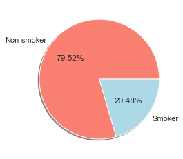

```python
ins_smoking = ins.groupby('smoker').age.count()
labels = ['Non-smoker', 'Smoker']
colors = ['salmon', 'lightblue']
plt.pie(ins_smoking, shadow=True, labels=labels, colors=colors, autopct="%0.2f%%")
plt.show()
```

Majority of insurance comapny clients are non-smokers. Let's look at how smoking impacts the insurence charges.

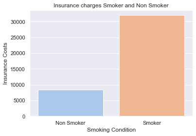

```python
smoker_ins = ins.groupby(['smoker']).charges.mean().reset_index()
sns.set_theme(palette="pastel")
ax = sns.barplot(x = 'smoker', y = 'charges', data = smoker_ins)
ax.set_xticklabels(['Non Smoker', 'Smoker'])
ax.set_xlabel('Smoking Condition')
ax.set_ylabel('Insurance Costs')
plt.title('Insurance charges Smoker and Non Smoker')
plt.show()
```